# Applied Microdata Analysis for Workforce Trends

# 4. Analyzing and Summarizing PUMS Data

In this section, we move from raw microdata to **PUMA-level workforce indicators**, a key use case for regional workforce analysis. Note: ACS 2019 uses **2010-based PUMAs**, which align with the 2019 PUMA shapefiles from `tigris`.

```r
nj_pums <- get_pums(
  variables = c("PUMA", "SEX", "AGEP", "SCHL"),
  state     = "NJ",
  survey    = "acs5",   # 5-year ACS PUMS for more stable small-area estimates
  year      = 2019,
  recode    = TRUE      # useful for labels in summaries
)
```

```r
# Quick example: weighted counts by sex and age
nj_pums %>%
  count(SEX_label, AGEP, wt = PWGTP)
```

| SEX_label | AGEP | n |
| --- | --- | --- |
| Male | 0 | 49615 |
| Male | 1 | 52892 |
| Male | 2 | 54351 |
| Male | 3 | 54432 |
| Male | 4 | 54254 |
| Male | 5 | 52829 |
| Male | 6 | 52641 |
| Male | 7 | 53474 |
| Male | 8 | 54679 |
| Male | 9 | 56246 |

[output cut: 180 more lines]

## 4.1 Group-wise summary: BA+ attainment by PUMA and sex

We will compute:

- Total population by PUMA and sex
- Mean age by PUMA and sex
- Number and share of adults 25+ with **BA or higher**

`SCHL` codes for BA+ (confirm in `pums_variables`):

- 21 = Bachelor’s degree
- 22 = Master’s degree
- 23 = Professional school degree (JD, MD, etc.)
- 24 = Doctorate degree

```r
nj_pums_summary <- nj_pums %>%
  mutate(
    ba_above = ifelse(SCHL %in% c("21", "22", "23", "24"), 1, 0)  # Create a dummy variable for BA+ education
  ) %>%
  group_by(PUMA, SEX_label) %>%
  summarize(
    total_pop = sum(PWGTP),                                       # Person-weighted total population by PUMA and sex
    mean_age  = weighted.mean(AGEP, PWGTP),                       # Person-weighted mean age by PUMA and sex
    ba_above = sum(PWGTP[ba_above == 1 & AGEP >= 25]),             # Person-weighted count of adults 25+ with BA or higher by PUMA and sex
    ba_above_pct = 100 * ba_above / sum(PWGTP[AGEP >= 25]),       # Percentage of adults 25+ with BA+ by PUMA and sex
    .groups = "drop"
  )
```

```r
# View the PUMA-level summary table
head(nj_pums_summary)
```

| PUMA | SEX_label | total_pop | mean_age | ba_above | ba_above_pct |
| --- | --- | --- | --- | --- | --- |
| 00101 | Male | 53151 | 40.88962 | 9929 | 26.96266 |
| 00101 | Female | 55453 | 43.20841 | 11050 | 27.71021 |
| 00102 | Male | 70771 | 38.32152 | 12120 | 25.57286 |
| 00102 | Female | 76370 | 40.35411 | 15806 | 29.53233 |
| 00301 | Male | 53839 | 37.47146 | 14805 | 39.94765 |
| 00301 | Female | 58718 | 40.97386 | 19422 | 46.02370 |

### Exercises: Group Summaries

1. Define a dummy variable for **high school or less** (e.g., `SCHL` codes up to HS) and compute its percentage by PUMA and sex.
2. Restrict the analysis to **prime-age adults (25–54)** and recompute BA+ shares.
3. Among females, identify which PUMA has the highest BA+ % and discuss potential workforce implications.

Participants can try:

```r
nj_pums_summary %>%
  filter(SEX_label == "Female") %>%
  arrange(desc(ba_above_pct)) %>%
  head()
```

| PUMA | SEX_label | total_pop | mean_age | ba_above | ba_above_pct |
| --- | --- | --- | --- | --- | --- |
| 01001 | Female | 55032 | 41.99342 | 25526 | 65.44457 |
| 01902 | Female | 55251 | 41.22159 | 25202 | 64.95863 |
| 01504 | Female | 61418 | 42.15365 | 28272 | 64.50376 |
| 00305 | Female | 53260 | 43.06962 | 24552 | 64.15637 |
| 01404 | Female | 52374 | 43.09404 | 23905 | 63.01236 |
| 01403 | Female | 56442 | 41.89231 | 25143 | 62.52456 |

# 5. Mapping PUMS Indicators by PUMA

Now we bring together:

- PUMA-level indicators from PUMS
- PUMA boundary shapefiles from `tigris`

to create a **workforce skills map**.

## 5.1 Downloading PUMA boundaries

```r
# Cache geometries locally to avoid repeated downloads
options(tigris_use_cache = TRUE)

# PUMAs for New Jersey (2010-based PUMAs used with 2019 ACS)
nj_pumas <- pumas(
  state = "NJ",
  cb    = TRUE,    # use generalized (cartographic) boundaries – simpler shapes
  year  = 2019
)
```

```r
# Check the PUMA shapefile structure
nj_pumas
```

| STATEFP10 | PUMACE10 | AFFGEOID10 | GEOID10 | NAME10 | LSAD10 | ALAND10 | AWATER10 | geometry |
| --- | --- | --- | --- | --- | --- | --- | --- | --- |
| 34 | 00800 | 7950000US3400800 | 3400800 | Hunterdon County | P0 | 1108120064 | 24767147 |  |
| 34 | 00601 | 7950000US3400601 | 3400601 | Hudson County (Central)--Jersey City (North) | P0 | 16447840 | 2573506 |  |
| 34 | 01700 | 7950000US3401700 | 3401700 | Warren County | P0 | 923228154 | 15744375 |  |
| 34 | 00702 | 7950000US3400702 | 3400702 | Hudson County (Northeast)--Union City & Hoboken Cities | P0 | 8615403 | 3730870 |  |
| 34 | 02400 | 7950000US3402400 | 3402400 | Cumberland County (South)--Vineland & Millville Cities | P0 | 937817523 | 495878743 |  |
| 34 | 02103 | 7950000US3402103 | 3402103 | Camden County (South & West)--Bellmawr & Pine Hill Boroughs | P0 | 331414604 | 4220372 |  |
| 34 | 01001 | 7950000US3401001 | 3401001 | Somerset County (North & West) | P0 | 406811302 | 2930707 |  |
| 34 | 01402 | 7950000US3401402 | 3401402 | Essex County (South Central)--East Orange City | P0 | 40864753 | 24328 |  |
| 34 | 02500 | 7950000US3402500 | 3402500 | Salem & Cumberland (North) Counties--Bridgeton City | P0 | 1173658925 | 112380442 |  |
| 34 | 02600 | 7950000US3402600 | 3402600 | Cape May & Atlantic (South Central) Counties--Ocean City & Somers Point City | P0 | 661711752 | 958185595 |  |

[output cut: 63 more lines]

## 5.2 Joining PUMS summaries to PUMA geography

We join on:

- `PUMACE10` in the shapefile (2010 PUMA code)
- `PUMA` in the PUMS summary

Then, as an example, we filter to **females** only.

```r
joined_pumas <- nj_pumas %>%
  left_join(
    nj_pums_summary,
    by = c("PUMACE10" = "PUMA")
  ) %>%
  filter(SEX_label == "Female")
```

```r
# Check that join worked and BA+ variables are present
head(
  joined_pumas %>%
    select(PUMACE10, NAME10, SEX_label, ba_above_pct)
)
```

|  | PUMACE10 | NAME10 | SEX_label | ba_above_pct | geometry |
| --- | --- | --- | --- | --- | --- |
| 1 | 00800 | Hunterdon County | Female | 52.83771 |  |
| 2 | 00601 | Hudson County (Central)--Jersey City (North) | Female | 57.35131 |  |
| 3 | 01700 | Warren County | Female | 33.08013 |  |
| 4 | 00702 | Hudson County (Northeast)--Union City & Hoboken Cities | Female | 51.49441 |  |
| 5 | 02400 | Cumberland County (South)--Vineland & Millville Cities | Female | 19.37769 |  |
| 6 | 02103 | Camden County (South & West)--Bellmawr & Pine Hill Boroughs | Female | 28.58471 |  |

## 5.3 Mapping BA+ attainment with `tmap`

We map:

- Variable: `ba_above_pct` (% of women age 25+ with BA+)
- Geography: PUMA boundaries
- Palette: `"Blues"` (you can experiment with others)

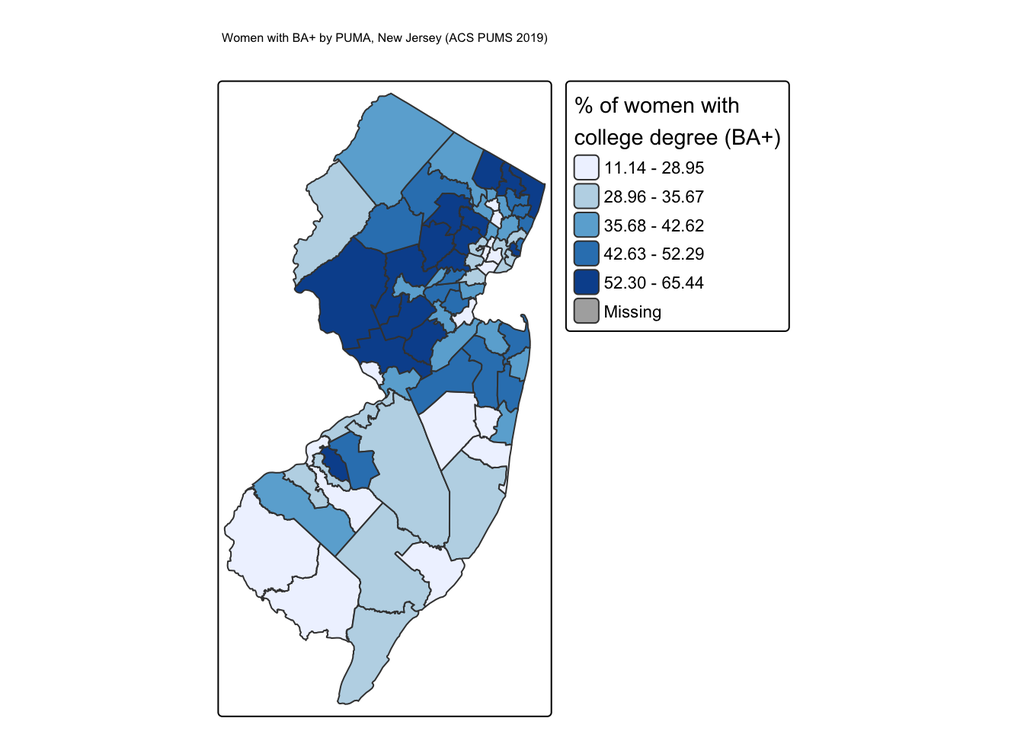

```r
# Use plot mode for static maps (suitable for knitted HTML/PDF)
tmap_mode("plot")

tm_shape(joined_pumas) +
  tm_polygons(
    col     = "ba_above_pct",            # variable to map
    palette = "Blues",                   # color palette
    style   = "quantile",                # classification style (e.g., quantile)
    title   = "% of women with\ncollege degree (BA+)"
  ) +
  tm_layout(
    legend.outside          = TRUE,
    legend.outside.position = "right",
    main.title              = "Women with BA+ by PUMA, New Jersey (ACS PUMS 2019)",
    main.title.size         = 1.1
  )
```

### Exercises: Mapping PUMS

1. Remove `filter(SEX_label == "Female")` and map **all sexes combined** (you may need to recompute summaries without splitting by sex).
2. Create a separate map for men only and compare visually with the women’s map.
3. Change `palette` to `"Viridis"` or `"Reds"` and discuss how color choices affect interpretation.
4. (Optional) Switch to interactive mode with `tmap_mode("view")` and explore the regions.

# Wrap-Up: Applied Microdata for Workforce Trends

In this session, we:

- Set up `tidycensus` with a Census API key.
- Explored PUMS variable metadata using `pums_variables`.
- Pulled ACS PUMS microdata with `get_pums()` for New Jersey.
- Interpreted identifiers and weights (`PWGTP`) to produce population-representative estimates.
- Used `recode = TRUE` to work with readable label columns.
- Applied `variables_filter` to efficiently restrict large PUMS pulls at the API.
- Aggregated microdata to create **PUMA-level workforce indicators** (e.g., BA+ attainment).
- Joined PUMS summaries with PUMA shapefiles from `tigris` and mapped results using `tmap`.

These steps form a reusable workflow for **applied microdata analysis** in workforce and economic development contexts:

1. **Define your question.**
2. **Find the right variables.**
3. **Pull microdata with proper weights.**
4. **Summarize to the right geographic unit.**
5. **Visualize patterns to inform policy and program decisions.**